# Explaining RMSE

Garcia

2023-01-25

## Error of the Unconditional Mean

The “variation/error” around the unconditional mean is just the standard deviation:

$$StandardDeviation(Y) = \sqrt{ 1/n
\sum_{i=1}^n(Y_i-\bar{Y_i})^2}.$$

This means that for our `sc_debt` data set, the standard deviation of `grad_debt_mdn` will be a metric of the average deviation or error around the mean.

Standard Deviation (`grad_debt_mdn`) = 6992

Does this look familiar? Perhaps something from the in-class RMD file?

```r
sc <- sc%>%
  mutate(mean_debt_uncond=mean(grad_debt_mdn, na.rm=TRUE))

rmse_uncond<-sc%>%
  rmse(grad_debt_mdn, mean_debt_uncond)

rmse_uncond
```

```
## # A tibble: 1 × 3
##   .metric .estimator .estimate
##   <chr>   <chr>          <dbl>
## 1 rmse    standard       6992.
```

So, the RMSE of the unconditional mean is just the standard deviation - an estimate of the error around the mean. That should not be surprising when we compare the equations for the standard deviation and the RMSE.

$$StandardDeviation(Y) = \sqrt{ 1/n
\sum_{i=1}^n(Y_i-\bar{Y_i})^2}$$

$$RMSE(\hat{Y})=\sqrt{ 1/n
\sum_{i=1}^n(Y_i-\hat{Y_i})^2}$$

The only appreciable difference here is that the standard deviation equation uses $\bar{Y_i}$ instead of $\hat{Y_i}$, but that should make sense as the unconditional mean *uses* the mean as the model (what is generating the predicted value).

## What does this mean for the Conditional Means?

We already saw how to find the RMSE for the conditional mean of `grad_debt_mdn` predicted by `control`:

```r
sc<-sc%>%
  group_by(control)%>%
  mutate(mean_debt_control=mean(grad_debt_mdn, na.rm=TRUE))%>%
  ungroup()

rmse_control<-sc%>%
  rmse(grad_debt_mdn, mean_debt_control)

rmse_control
```

```
## # A tibble: 1 × 3
##   .metric .estimator .estimate
##   <chr>   <chr>          <dbl>
## 1 rmse    standard       5701.
```

Well… we can also do it manually:

```r
# Break apart the data set by levels of `control`
sc.pri<-sc%>%
  filter(control=="Private")

sc.pub<-sc%>%
  filter(control=="Public")

# Not all obs are used in calculations of variance, so what are our ACTUAL Ns?
N.pri<-length(sc.pri$grad_debt_mdn[!is.na(sc.pri$grad_debt_mdn)])
N.pub<-length(sc.pub$grad_debt_mdn[!is.na(sc.pub$grad_debt_mdn)])
N.tot<-length(sc$grad_debt_mdn[!is.na(sc$grad_debt_mdn)])

# Variances for each level of `control`
var.pri<-var.p(sc.pri$grad_debt_mdn)
var.pub<-var.p(sc.pub$grad_debt_mdn)
```

The squareroot of the *weighted average* of the variances is then
$$\sqrt{ \frac{ N.pri*var.pri +
N.pub*var.pub}{N.tot} }$$

or 5701, matching the RMSE above.

## … but I’m a visual learner

Okay then. Graphically, what’s going on with the conditioning of means?

When we use a conditional mean we are breaking up/partioning the data into groups. Kinda like you did with t-tests and ANOVAs. The difference here is: We didn’t design these groups like you would for an experiment. We selected them from the data.

Let’s look at the distribution for `grad_debt_mdn` for the whole dataset:

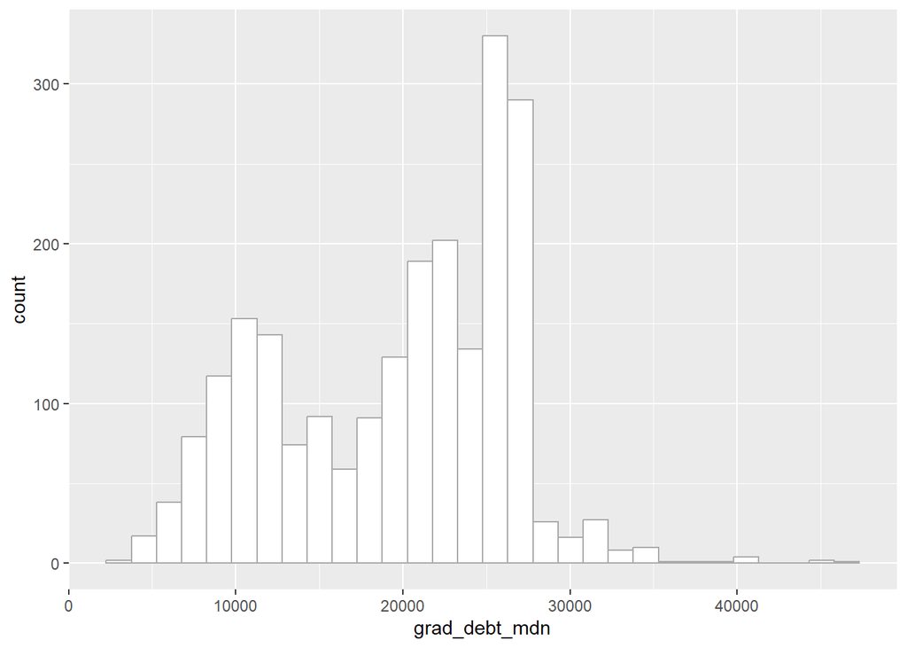

```r
# Entire sample
gg<-sc%>%
  ggplot(aes(x=grad_debt_mdn))+
  geom_histogram(color="darkgrey",fill="white")
gg
```

Now let’s add to that plot - overlaying the distributions for private and public.

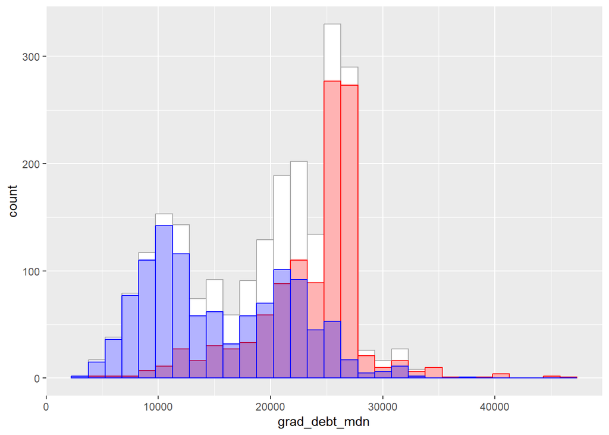

```r
# Just the Private Schools
gg1<-gg+ geom_histogram(data=sc.pri, color="red",fill="red",alpha=.3)

# Just the Public Schools
gg1<-gg1+ geom_histogram(data=sc.pub, color="blue",fill="blue",alpha=.3)
gg1
```

You should see that we have essentially taken the entire distribution and reallocated/partitioned the cases in the data set into one of the two levels of control. We have, in essense, expanded our model from one mean (in the case of the uncondtional mean) to a set of more than one (conditional mean).